# Avocado

Xinyue (Miranda) Ding, Chudi Zhong

## Introduction

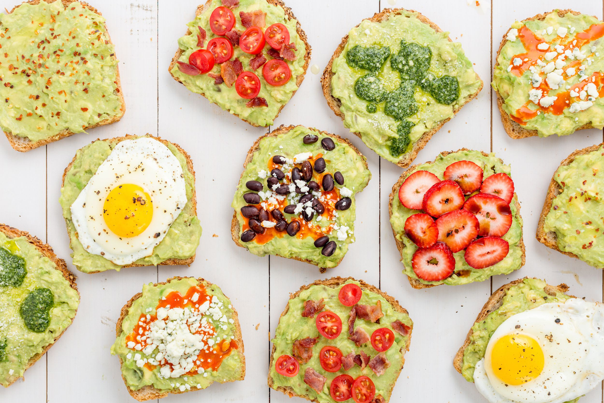

Avocado Toast: https://hips.hearstapps.com/del.h-cdn.co/assets/16/01/1452289733-avocado-toast.jpg

## Data Processing

```r
avocado = suppressMessages(read_csv("data/avocado.csv"))
avocado = avocado[,-1]
avocado = avocado %>% mutate(day = as.factor(day(Date)),
                             month = as.factor(month(Date)),
                             year = as.factor(year))
```

First of all, we visualize the average avocado price in the US from January 2015 to March 2018. Figure 1 indicates that the pattern of average prices for two types of avocado were similar, both of which were stable before mid of 2016, about $\$1.50$ per unit for organic avocado and about $\$1.00$ per unit for conventional avocado. In the summer of 2015, the price of organic avocado dropped tremendously for a while and then returned back. In 2017, the price for avocado had jumped up and reached the peak in the fall that year with more than $\$2.00$ per unit for organic avocado and $\$1.60$ per unit for conventional avocado. Figure 2 visualizes the avergae avocado price in the 53 regions. Comparing with the curve drawns based on the nationalwide data, we infer that geographic location may have the impact on the avocado price. Figure 3 and 4 use boxplot to illustrate the variation of the price by year, and we can get the similar insight as from the previous plots.

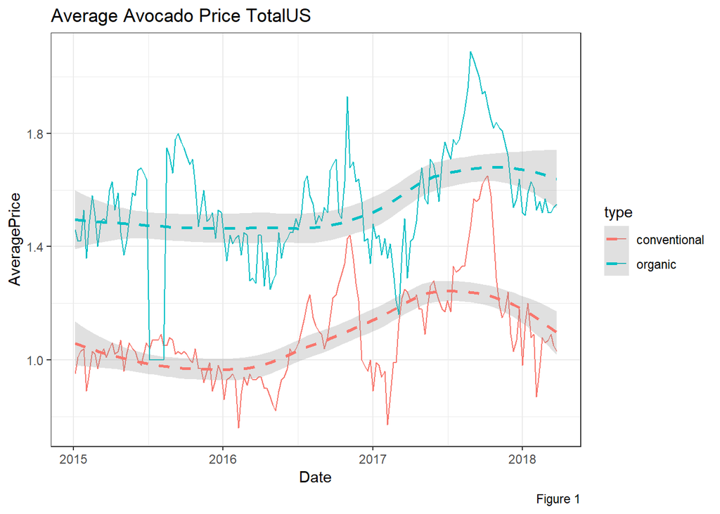

```r
### midsouth northeast southeast west
ggplot(data = avocado %>% filter(region=="TotalUS"),
       aes(x = Date, y = AveragePrice, color = type)) +
  geom_line() +
  geom_smooth(linetype = 2, alpha = 0.3)+
  theme_bw() +
  labs(title = "Average Avocado Price TotalUS", caption = "Figure 1")
```

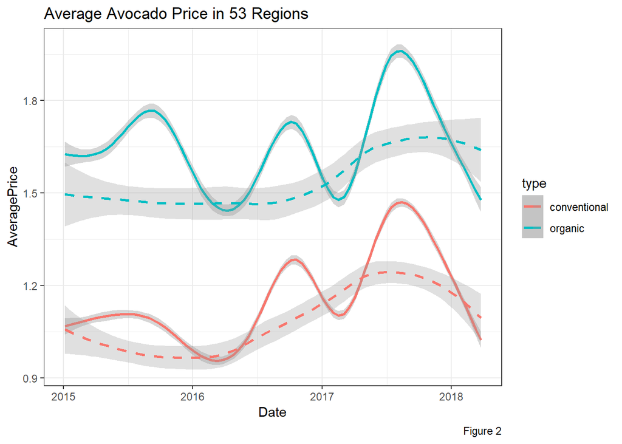

```r
ggplot(data = avocado %>% filter(region != "TotalUS"),
       aes(x = Date, y = AveragePrice, color = type)) +
  geom_smooth() +
  geom_smooth(data = avocado %>% filter(region=="TotalUS"), linetype = 2, alpha = 0.3) +
  theme_bw() +
  labs(title = "Average Avocado Price in 53 Regions", caption = "Figure 2")
```

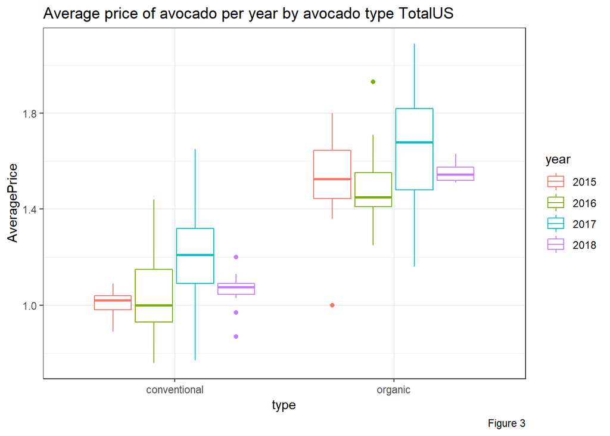

```r
ggplot(data = avocado %>% filter(region == "TotalUS"),
       aes(x = type, y = AveragePrice, color = year)) +
  geom_boxplot() +
  theme_bw() +
  labs(title = "Average price of avocado per year by avocado type TotalUS", caption = "Figure 3")
```

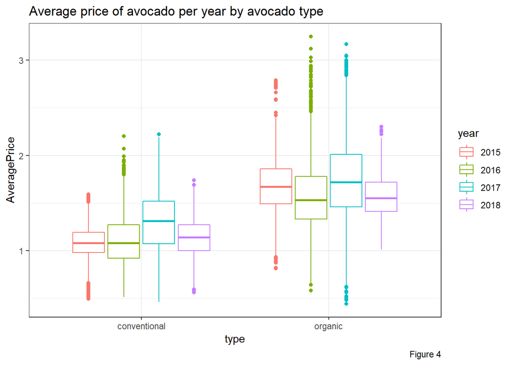

```r
ggplot(data = avocado %>% filter(region != "TotalUS"),
       aes(x = type, y = AveragePrice, color = year)) +
  geom_boxplot() +
  theme_bw() +
  labs(title = "Average price of avocado per year by avocado type", caption = "Figure 4")
```

## Scrap avocado recipes from loveonetoday.com

We write the code to scrap the data from the loveonetoday.com. Since the website has recipes in 46 pages, we first construct 46 URLs for each page and use `read_html function` to get the recipe URLs and corresponding image URLs. We finally get 405 recipe URLs and 405 image URLs. Then we use the `for loop` to obtain the `title`, `introduction`, `characteristics`, `cook time`, and `calories` for each recipe and store the information in a data frame. We delete the recipes without cook time and the data frame has 160 records. Then we apply the `stringr` package to clean the cook time. First of all, we transform all characters to lower case and then keep the shorter time if the stored information is a time interval, for example, replacing “3 hours on high or 6 hours on low in slow cooker” to “3 hours”. Then we replace the string “plus” or “and” to “+” and use “+” as the split index. Finally, we use the for loop and if statement to obtain the cook time in minutes for 160 recipes. The final data frame contains 160 recipes with 7 variables: `title`, `image_url`, `introduction`, `characteristics`, `calories`, `url`, and `time.minutes`. Since it takes a while to run the code, we save the data frame as a csv file, and in the next part, Shiny App, we will read the file to import the data.

```r
### page 1-46
page_base_url = "https://loveonetoday.com/avocado-recipes/page"

TITLE = c()
IMAGE = c()
RECIPE = c()
for (id in 1:46) {
  page_num = paste0(id, "/")
  page_url = file.path(page_base_url, page_num)
  page = read_html(page_url)
  title = page %>% html_nodes(".title") %>% html_text()
  l = length(title)
  TITLE = c(TITLE,title[c(-1, -l+2, -l+1, -l)])
  image = as.character(page %>% html_nodes("a") %>% html_nodes("img"))
  IMAGE = c(IMAGE, image[c(-1, -l+2, -l+1, -l)])
  recipe = as.character(page %>% html_nodes("h2 a"))
  RECIPE = c(RECIPE, recipe)
}


### get image and recipe url
image_url = c()
image_split = strsplit(IMAGE, " ")
recipe_url = c()
recipe_split = strsplit(RECIPE, "\\/")
for (i in 1:length(IMAGE)) {
  image = image_split[[i]][4]
  image_link = substr(image, 6, (str_length(image)-1))
  image_url = c(image_url, image_link)

  recipe = recipe_split[[i]][5]
  recipe_link = paste0("https://loveonetoday.com/recipe/", recipe)
  recipe_url = c(recipe_url, recipe_link)
}



### scrap recipe

avocado_recipe = NULL
for (i in 1:length(recipe_url)){

  url = recipe_url[i]
  recipe_page = read_html(url)

  ### get introduction
  intro = recipe_page %>%
    html_nodes("p") %>%
    html_text()
  intro = intro[3]

  ### characterstic
  character = recipe_page %>%
    html_nodes("p") %>%
    html_nodes("a") %>%
    html_text()
  l.c = length(character)
  characters = paste(character[-c(1, (l.c-3):l.c)], collapse = ", ")

  ### time
  time.length = recipe_page %>%
    html_nodes("dd") %>%
    html_text()
  l = length(time.length)
  if (l>2) {
    time.length = time.length[2]
  } else {
    time.length = NA
  }

  ### get calories
  calor = recipe_page %>%
    html_nodes(".h4") %>%
    html_node("td") %>%
    html_text() %>%
    str_remove_all("\t") %>%
    str_remove_all("\n") %>%
    as.numeric()

  recipe_info = cbind(TITLE[i], image_url[i], intro, characters, time.length, calor, url)

  avocado_recipe = rbind(avocado_recipe, recipe_info)

}

avocado_recipe= avocado_recipe %>%
  as.data.frame() %>%
  filter(!is.na(time.length))
colnames(avocado_recipe) = c("title", "image_url", "introduction", "characteristics", "time", "calories", "url")

### get cook time in munites
time = as.character(avocado_recipe$time)
time = tolower(time)
time = gsub("\\(|\\)"," ", time)
time = str_replace_all(time, "3 hours on high or 6 hours on low in slow cooker", "3 hours")
time = str_replace_all(time, "2 to 5", "2")
time = str_replace_all(time, "1 to 2", "1")
time = str_replace_all(time, "8 to 14", "8")
time = str_replace_all(time, "7-9", "7")
time = str_replace_all(time, "25 - 30", "25")


time = str_replace_all(time, "plus|and", "+")
time = gsub("\\s+"," ", time)

time = strsplit(time, "\\+")
time.minutes = c()
for (i in 1:nrow(avocado_recipe)) {
    l = length(time[[i]])
    mins = 0
    for (j in 1:l){
      time.mh = 0
      if(str_detect(time[[i]][j], "minutes") & str_detect(time[[i]][j], "hour")){
        t.mh = as.numeric(str_extract_all(time[[i]][j], "\\d+")[[1]])
        time.mh = t.mh[1]*60 + t.mh[2]
      } else if(str_detect(time[[i]][j], "minutes")) {
        time.mh = as.numeric(str_extract(time[[i]][j], "\\d+")[[1]])
      } else if(str_detect(time[[i]][j], "hour")) {
        time.mh = as.numeric(str_extract(time[[i]][j], "\\d+")[[1]])*60
      }

      mins = mins + time.mh
    }

  time.minutes=c(time.minutes, mins)
}

avocado_recipe = cbind(avocado_recipe, as.data.frame(time.minutes)) %>% select(-time)
write.csv(avocado_recipe, "avocado_recipe.csv")
```

## Shiny App

We use the `shiny` package to create a shiny app. First of all, we import the CSV file obtained from the previous part. The shiny app has a sidebar which allows users to select the ranges of calorie and cook time, characteristics of recipe such as “vegan” and “quick & easy”. We also incorporate the run button to initiate the information retrieval. The main panel will return the filter selections and the titles of recipes that satisfy the requirements. Once the user clicks the link, a modal dialog box will pop up, listing the title, introduction, labels, cook time, calories, image as well as a link to the full recipe on the loveonetoday.com.

```r
library(shiny)

recipe <- read.csv("data/avocado_recipe.csv", stringsAsFactors = FALSE) %>%
  as_tibble() %>%
  select(-X) %>%
  janitor::clean_names()

feature <- c(
  "New", "Popular", "Quick & Easy", "Heart-Healthy",
  "Guacamoles & Dips", "Fall", "Summer"
)
health <- c(
  "Vegan", "Vegetarian", "Meals Under 500 Calories", "Snacks Under 200 Calories", "Dairy-Free",
  "Egg-Free", "Soy-Free", "Gluten-Free", "Grain-Free", "Fiber-Rich", "Good Source of Protein",
  "No Added Sugars", "Low Sodium"
)


shinyApp(
  ui <- fluidPage(
    titlePanel("Avocado Recipe"),

    sidebarLayout(
      sidebarPanel(

        tabsetPanel(
              tabPanel(
                h5("calories and time"),
                sliderInput("calories", "Calories Range",
                  min = min(recipe$calories, na.rm = TRUE),
                  max = max(recipe$calories, na.rm = TRUE),
                  value = c(200, 1200)
                ),
                sliderInput("time", "Cooking Time Range",
                  min = min(recipe$time_minutes, na.rm = TRUE),
                  max = max(recipe$time_minutes, na.rm = TRUE),
                  value = c(0, 100)
                )
              ),
              tabPanel(
                h5("Feature labels"),
                checkboxGroupInput("feature", label = "feature", choices = feature)
              ),
              tabPanel(
                h5("Health labels"),
                checkboxGroupInput("health", label = "health", choices = health)
              )
            ),

        # Run button
        actionButton("run", "Go Avocado!")
      ),

      mainPanel(
        uiOutput("selections"),
        uiOutput("recipes")
      )
    )
  ),

  server <- function(input, output, session) {

    # model dialog
    recipeInfo <- function() {
      modalDialog(
        h4("Name"),
        textOutput("title"),
        h4("Introduction"),
        textOutput("introduction"),
        h4("Labels"),
        textOutput("characteristics"),
        h4("Cooking Time (in minutes)"),
        textOutput("time"),
        h4("Calories"),
        textOutput("calories"),
        br(),
        htmlOutput("image_url"),
        br(),
        uiOutput("url"),
        easyClose = TRUE
      )
    }

    # Get filter result
    search <- eventReactive(
      input$run, {
        print("Filter Avocado Recipes...")
        df <- recipe %>%
          filter(calories >= input$calories[1] & calories <= input$calories[2]) %>%
          filter(time_minutes >= input$time[1] & time_minutes <= input$time[2])

        temp <- NULL
        if (length(input$feature) != 0) {
          for (i in 1:length(input$feature)) {
            temp <- cbind(temp, str_detect(df$characteristics, input$feature[i]))
          }
        }
        if (length(input$health) != 0) {
          for (i in 1:length(input$health)) {
            temp <- cbind(temp, str_detect(df$characteristics, input$health[i]))
          }
        }
        if (length(input$feature) != 0 | length(input$health) != 0) {
          temp <- rowSums(temp)
          df <- df %>%
            mutate(logictest = temp) %>%
            filter(logictest == (length(input$feature) + length(input$health))) %>%
            select(-logictest)
        }
      df
      }
    )

    # Get filter inputs
    get_selections <- eventReactive(
      input$run,
      list(
        paste(input$calories[1], "~", input$calories[2]),
        paste(input$time[1], "~", input$time[2]),
        input$health,
        input$feature
      )
    )

    # Show filter selections
    observeEvent(
      get_selections(),
      output$selections <- renderUI(
        fluidPage(
          h4("Filter Selections:"),
          renderText(c("Calories Range:", get_selections()[[1]])),
          renderText(c("Time Range:", get_selections()[[2]])),
          renderText(c("Health Labels:", paste(get_selections()[[3]], collapse = ", "))),
          renderText(c("Feature Labels:", paste(get_selections()[[4]], collapse = ", ")))
        )
      )
    )

    observeEvent(
      search(), {

        # Get current existing observers
        state <- reactiveValues(
          observers = list()
        )

        # Destroy existing observers
        for (i in seq_along(state$observers)) {
          state$observers[[i]]$destroy()
        }

        # Create new UI elements (fluidpage of fluidrows for links)
        output$recipes <- renderUI(
          fluidPage(
            h4("Recipes:"),
            if (nrow(search()) == 0) {
              renderText("Woops! No results matched!")
            } else {
              renderText(paste("We found", nrow(search()), "avocado recipes for you!"))
            },
            br(),br(),
            map(
              seq_len(search() %>% nrow()),
              function(i) fluidRow(
                  actionLink(paste0("link", i), search()[["title"]][i])
                )
            )
          )
        )

        # Reset and create new observers for each of our links
        state$observers <- map(
          seq_len(search() %>% nrow()),
          function(i) {
            label <- paste0("link", i)
            observeEvent(
              input[[label]], # correspond to the fluidRows
              {
                cat("You clicked link ", i, "!\n", sep = "")

                # Text
                output$title <- renderText(search()[["title"]][i])
                output$introduction <- renderText(search()[["introduction"]][i])
                output$characteristics <- renderText(search()[["characteristics"]][i])
                output$time <- renderText(search()[["time_minutes"]][i])
                output$calories <- renderText(search()[["calories"]][i])

                # Image
                src <- search()[["image_url"]][i]
                if (!is.na(src)) {
                  output$image_url <- renderText({
                    c('<img src="', src, '" width="450">')
                  })
                } else {
                  output$image <- NULL
                }

                # URL
                url <- a("Read it on loveonetoday website", href = search()[["url"]][i])
                output$url <- renderUI(tagList("Web URL:", url))

                showModal(recipeInfo())
              },
              ignoreInit = TRUE
            )
          }
        )
      }
    )
  }
)
```

Shiny applications not supported in static R Markdown documents

### Reference

https://en.wikipedia.org/wiki/Hass_avocado

https://www.kaggle.com/neuromusic/avocado-prices

https://loveonetoday.com/avocado-recipes/